# USA Youth Tobacco Use

Sophia Frantz

12/9/2019

# The CDC National Youth Tobacco Use Survey

The CDC conducts this survey in order to understand the prevalence of cigarette use among teenagers in the United States. Through surveys, they measure factors such as the percentage of teens who currently smoke, percentage who have ever smoked, percentage who have tried to quit in the past year, percentage who want to quit, and the percentage who are frequenct smokers. The CDC also collects accompanying information to describe the students who take the survey such as the state they reside and their education status (middle or high school) and gender.

In this report, I will analyze how cigarette use in teenagers changes over time. I will analyze a subset of teenage smokers, the current users, defined by the CDC as “Percentage of students who reported that they had smoked cigarettes on one or more days of the 30 days preceding the survey.” I will analyze cigarette use in this group over time for the years 1999-2017. The purpose of this analysis is to fit an appropriate model that describes the existing data so that I can estimate cigarette usage for years when no survey was performed I will also use this model to predict cigarette usage in the future.

# Viewing the Data

Before fitting the model, I will provide some information about the quality, type, and features of the data.

First of all, data is absent from 5 states: Alaska, Montana, Nevada, Oregon, Washington. There is also no information in this dataset about cigarette usage in any U.S. territories.

Further, cigarette use is not reported for every year. In states that conduct the survey regularly, data was collected once every other year. The amount of data is variable for each state, especially in terms of years the data was collected. We can see in the plot below that some states, such as Alabama, reported data consistently every other year. Some other states only have estimates for one year, such as Colorado, Texas, and Wyoming, which only report data for the year 2000.

Information about when each state reports data is visualized in the plot below. The states are listed in alphabetical order on the x-axis. On the y-axis is every year represented in this dataset, 1999-2017. A dot indicates if data exists for a particular state during a particular year.

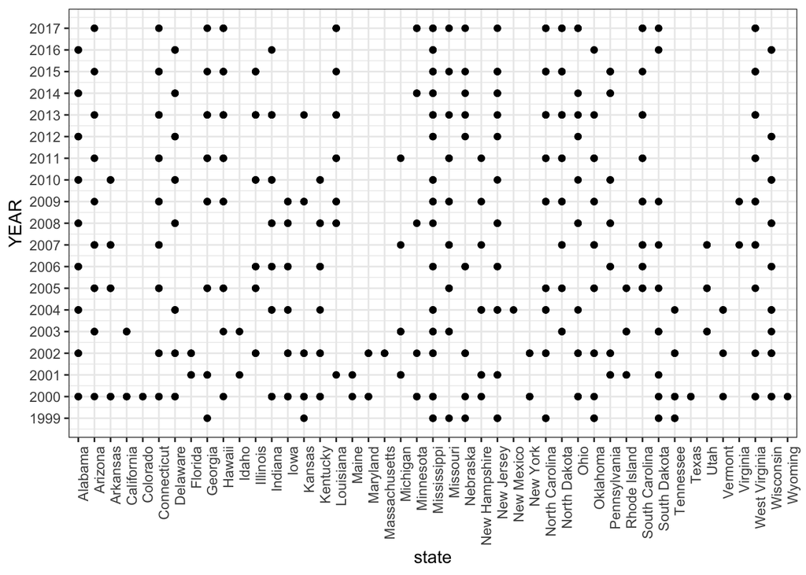

The inconsistency of data in some states is one good reason for creating a model. By combining the data from all the states, we can make estimates for states with sparse data, such as Utah, which only reports data for 3 years. We can also use the model to predict future cigarette usage for certain groups, such as state of residence, education status, and gender.

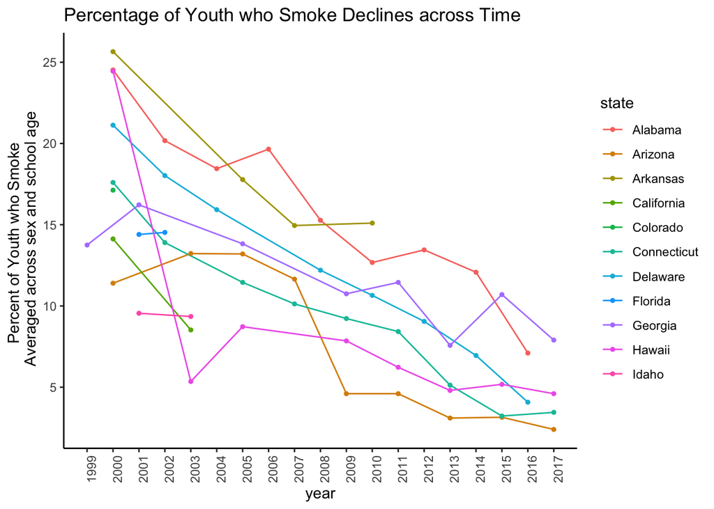

I am also interested in how gender and education status infuences cigarette usage, so I will test whether they contribute to the estimate in the model. Below I have shown differences between middle and high school students and between male and female students for the first and last year of the study. Gender is represented with 2 different colors and education is represented with 2 different shapes. It seems that more high schoolers smoke than middle schoolers in all states. It is more difficult to tell whether more males smoke than females or vice versa.

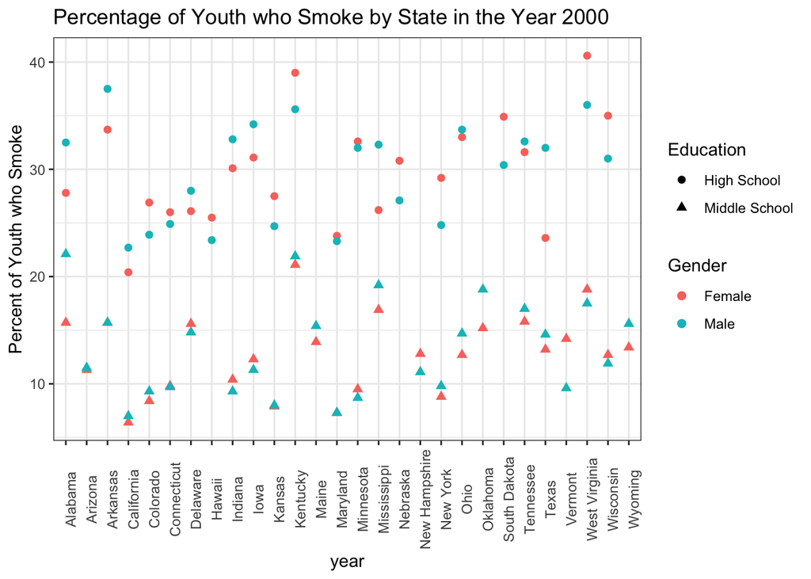

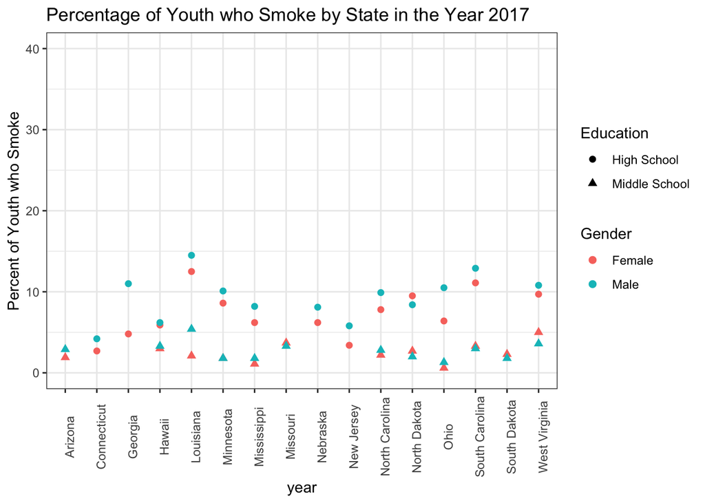

# Fitting a Model to the Data

I used a generalized linear model to estimate how state, education level, and gender contribute to cigarette use over time. I defined my model as follows: out of the total number of students surveyed, the number of students who said they regularly use cigarettes is determined by theone or an additive combination of the following: state, education, gender, and year. I allowed each combination of state, gender, and year has its own intercept (point at which it crosses the y-axis, which is the first year of the survey, 1999). The slope (the rate at which cigarette use changes) is determined by the year, and each state has the same slope. I modeled the noise in the data with a binomial distribution. I used this distribution because it fits with the type of data I am using from the Youth Tobacco Survey. The binomial models success/failure, and the answer to the question of whether teens have smoked in the past 30 days is yes/no.

To check if all these predictors add to the model and to make sure I am not overfitting the model, I compared the value of the AIC for models which drop one predictor at a time. AIC is a measure of model fit that allows for comparison of models as long as they have the same data and distribution of noise. I used a binomial distribution in all the models I compared, so AIC is appropriate for comparison. I also compared these models with a model in which each state has its own slope, which means the model allows the rate of change in cigarette use to be different for each state.

```
##                                   dAIC    df
## year only                         52134.3 2
## state                             42915.7 46
## state+Education                     207.9 47
## state+Education+Gender                0.0 48
## state+Education+Gender+State:year 66131.0 87
```

Above, the models tested are named. dAIC is the difference between the given model AIC and the best model’s AIC value. Thus, the best model has an AIC value of 0. df = degrees of freedom used to fit the model.

The results show that that the model including state, education, and gender is the best fit. However, the state + education model is not much different, and so it seems that gender is improving the fit of the model but not by very much. Adding an interaction between state and year does not improve the model, likely because it reduces our degrees of freedom and thus power to fit the model.

I also wanted to compare the above model to a model in which I treat state as a random effect. Treating state as a random effect will free some degrees of freedom and give me more data and thus power to predict. However, if cigarette use differs substantially depending on state, which just from looking at the data seems to be possible, then treating state as a random effect will not reflect the truth about cigarette usage.

# Model Comparison: Should state be treated as a random effect?

I could not use AIC in this same way to compare a standard GLM with a GLM that includes random effects. So instead I used ANOVA to compare the the differences in the results of the two models. This comparison then gave me an AIC value so that I could compare.

| random effect of state | 11253 |
| --- | --- |
| predictions for each state | 11063 |

The results above show that the model with estimates for each state is slightly better than the model with random effects for state. I am choosing the model which treats each state differently because I think this model is more informative for the question we are asking with the Youth Tobacco Survey. Thus I will obtain estimates for each state because the CDC may want to know if certain states are more at-risk than others so that intervention can be targeted toward the appropriate states

# Model and estimates of uncertainty

The final model I used to predict cigarette usage is a generalized linear model in which state, education, and gender determine cigarette usage over time. I used a binomial distribution to model the deviation from the mean of this estimate. The estimates for each predictor (points) and the estimates of uncertainty (lines) are shown below.

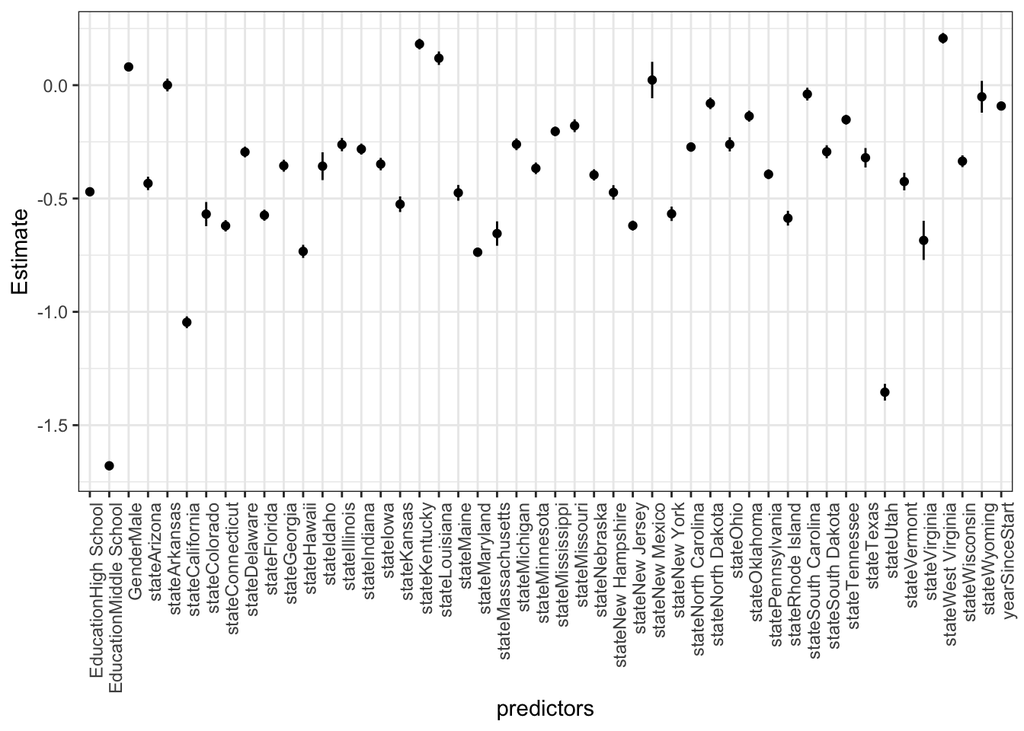

Starting with the terms on the left, we can see that middle schoolers smoke much less than high schoolers and that males smoke slightly more than females. The value for females is not shown because it is set at 0 and males are relative to females. Becase the value for males is above 0, this means the value is higher than females and thus males smoke more. Estimates for each state are then shown, and from this we can see that cigarette usage differs based on state. Similar to the case for male/female estimates, Alabama’s estimate is not shown because it is the default value (set at 0) and every other state is relative to Alabama. For example, Utah’s estimate is negative and much lower than 0, so it has a much lower percentage of smokers overall. In fact, it has the lowest state effect.

# Predictions for New Jersey 2019

Now that we have calculated estimates for each group, we can use these estimates to make predictions for what cigarette use will be in the future. If the CDC is interested in future trends of a particular group, say female high schoolers in Utah and New Jersey, then I can use my model to predict this trend.

Below I have shown the predictions for every year up to 2019. The predicted percentage of female high schoolers who will be smokers in New Jersey in 2019 is 0.53 or 5% (0.053 +/- 0.00088).

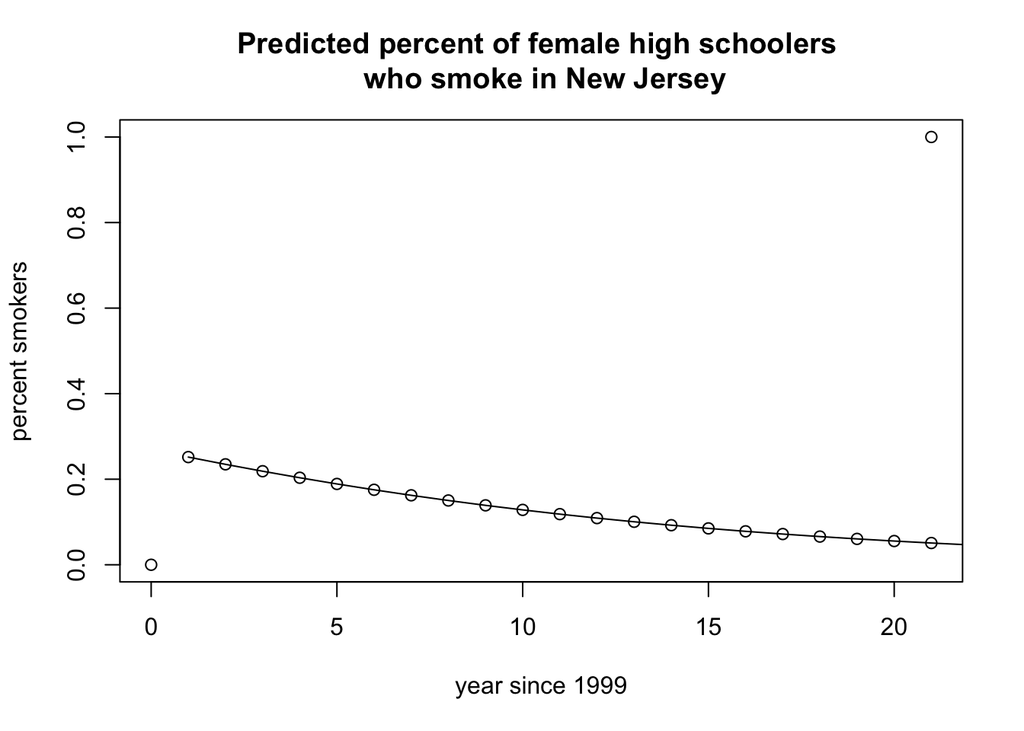

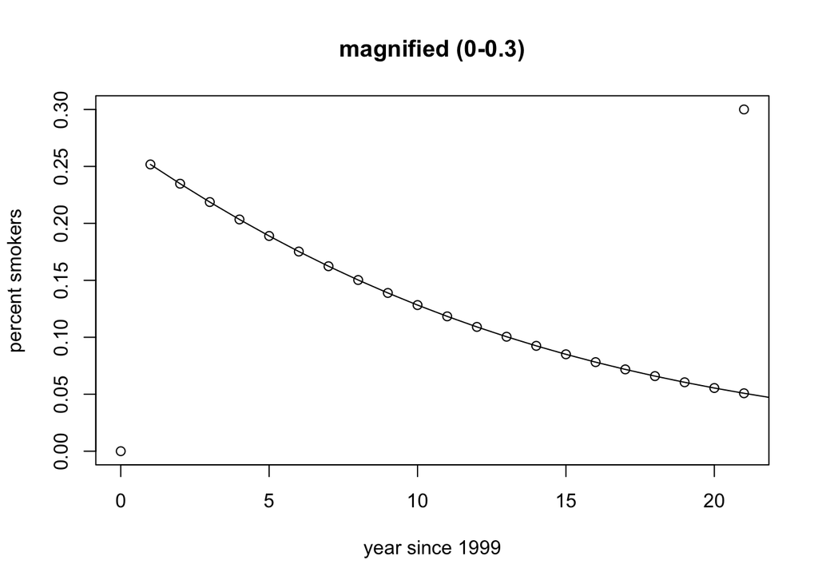

# Predictions for Utah 2019

I have performed the same prediction as above but this time I have predicted Utah. The predicted percentageof female high school smokers in Utah for 2019 is 0.027 (+- 0.0009), so about 3%. We can see from these plots that cigarette usage declines over the years for both states and that Utah has a lower proportion of female high school smokers.

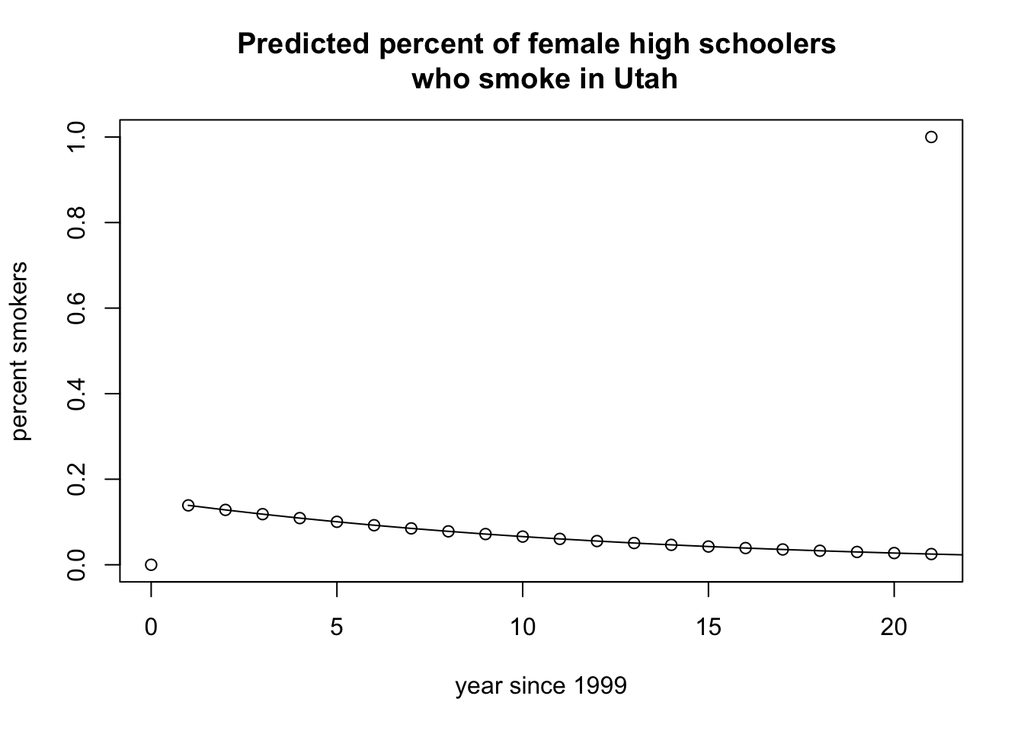

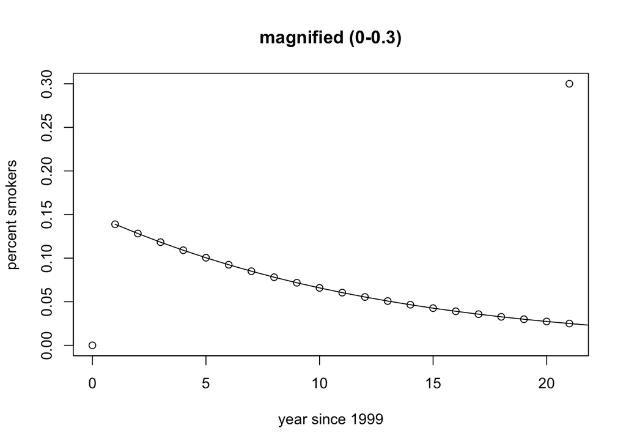

# More on 2019 Prediction: Cross-validation with out-of-sample prediction

| State | Predicted | SE | Actual | Year |
| --- | --- | --- | --- | --- |
| New Jersey | 0.0677 | 0.001 | 0.034 | 2017 |
| Utah | 0.0330 | 0.001 | 0.057 | 2007 |

# Regional Predictions

I predicted 2019 cigarette usage for every state the same way I predicted it for Utah and New Jersey. In order to help the CDC plan for specific intervention efforts based on state, I have displayed information about future cigarette usage for each state. Percent usage is indicated with a color scale. There is no data for the states shown in gray. Brighter red indicates a higher predicted usage and so possibly a more at-risk state.

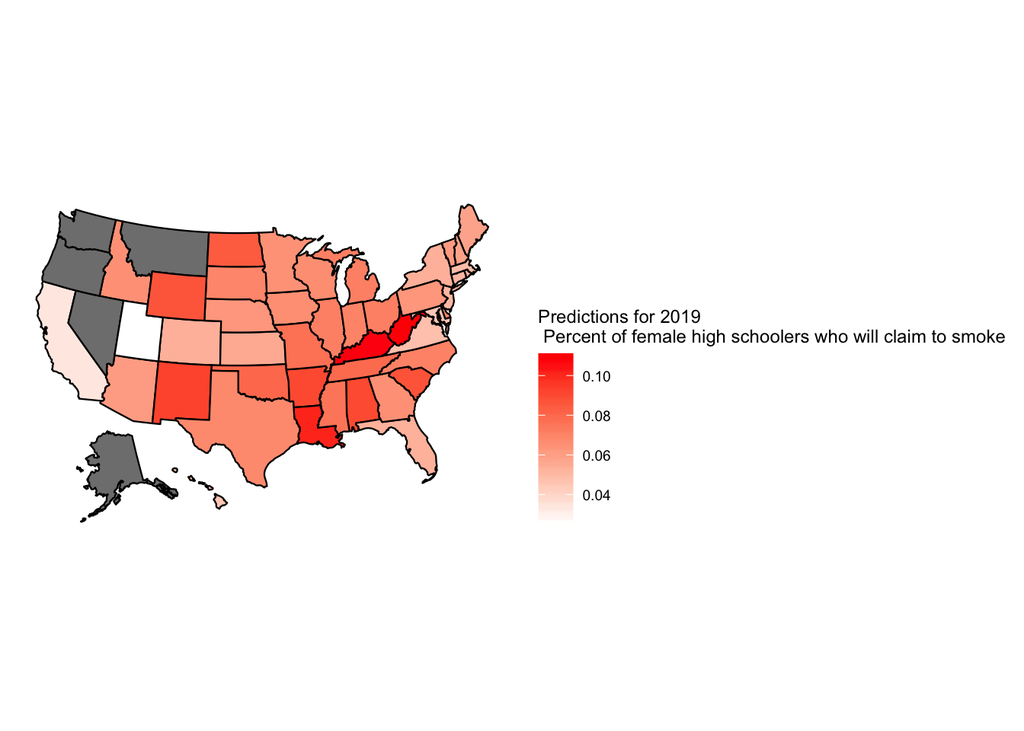

# Conclusion

The CDC should take the effects of gender, education status, and state into account when making decisiona about youth tobacco usage. Male students tend to smoke slightly more than female students. High school students smoke more than middle school students. Cigarette usage differs by state but the rate of decline does not differ very much by state. However, the CDC should also consider the growing rise of tobacco usage through e-cigarettes and realize the trends explored in this report may not necessarily apply to e-cigarette usage.